# Forecasting models on time series

### 3. Models

Including Mean, Naive, Random walk, seasonal Naive, moving average, Simple Exponential Smoothing, Holt’s Trend and Holt winter models

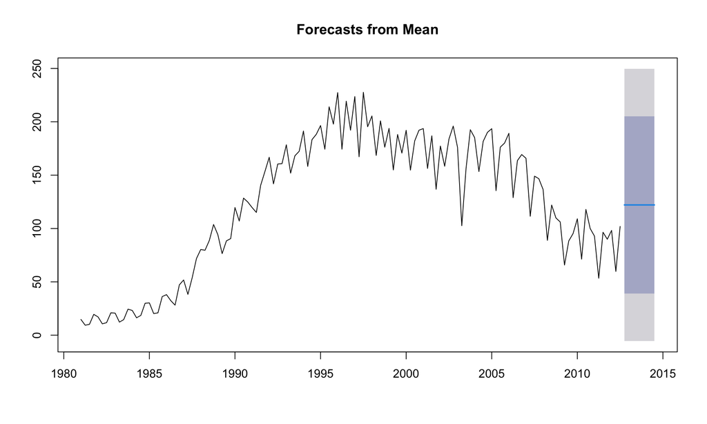

```r
# Mean
mean_forecast <- meanf(arrivals[,"Japan"],8)
plot(mean_forecast)
```

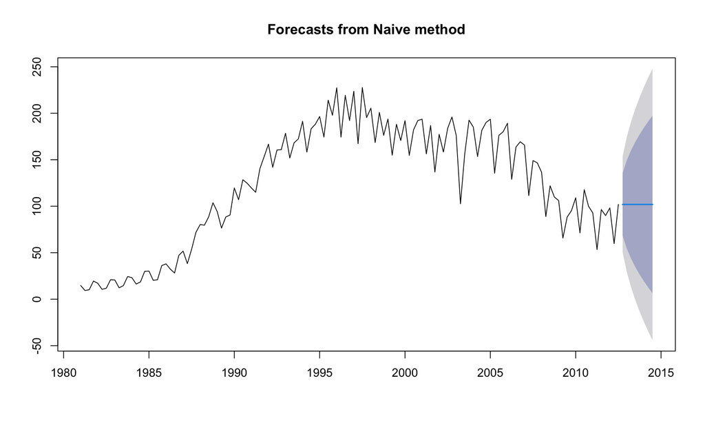

```r
# Naive
naive_forecast <- naive(arrivals[,"Japan"],8)
plot(naive_forecast)
```

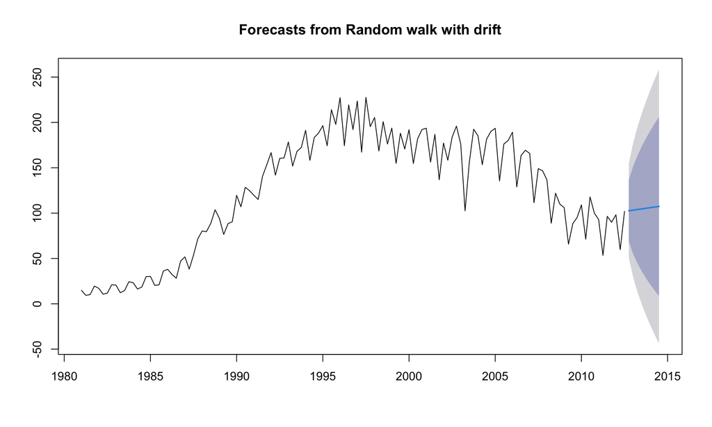

```r
# Random Walk
rwf_forecast <- rwf(arrivals[,"Japan"],8, drift=TRUE)
plot(rwf_forecast)
```

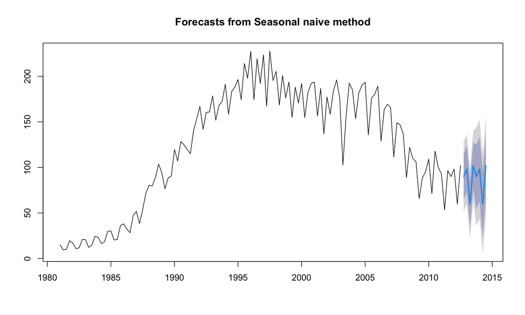

```r
# Seasonal Naive
snaive_forecast <- snaive(arrivals[,"Japan"],8)
plot(snaive_forecast)
```

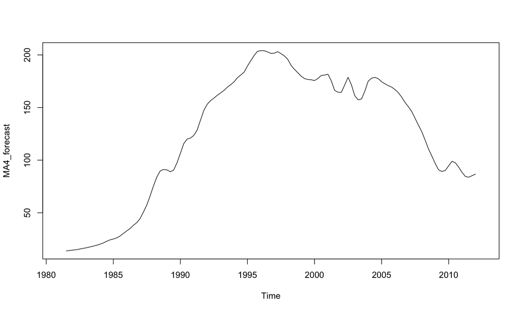

```r
# Moving Averages
MA4_forecast <- ma(arrivals[,"Japan"],order=4)
plot(MA4_forecast)
```

```r
forecast_MA4 <- forecast(MA4_forecast)
```

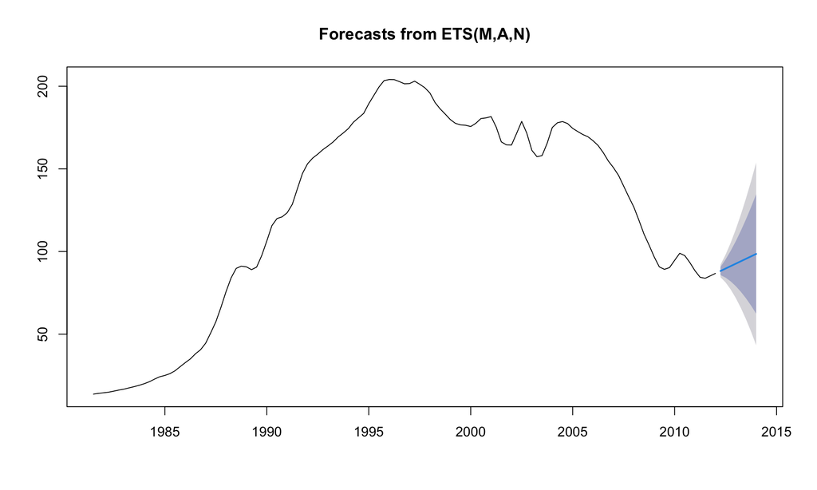

```r
plot(forecast_MA4)
```

```r
# Simple Exponential Smoothing
ses_forecast <- ses(arrivals[,"Japan"], h=8)
ses_forecast$model
```

```
## Simple exponential smoothing
##
## Call:
## ses(y = arrivals[, "Japan"], h = 8)
##
##   Smoothing parameters:
##     alpha = 0.3829
##
##   Initial states:
##     l = 13.3255
##
##   sigma:  21.2683
##
##      AIC     AICc      BIC
## 1395.729 1395.924 1404.262
```

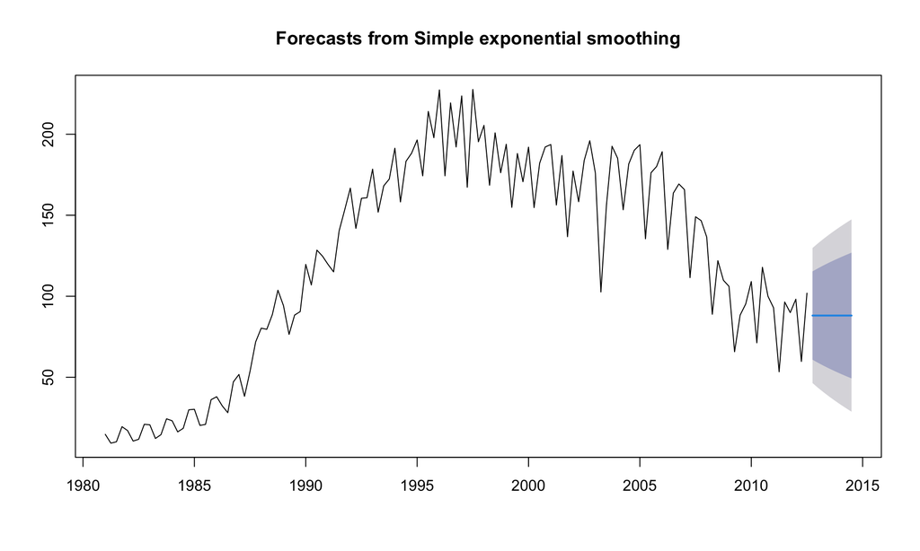

```r
plot(ses_forecast)
```

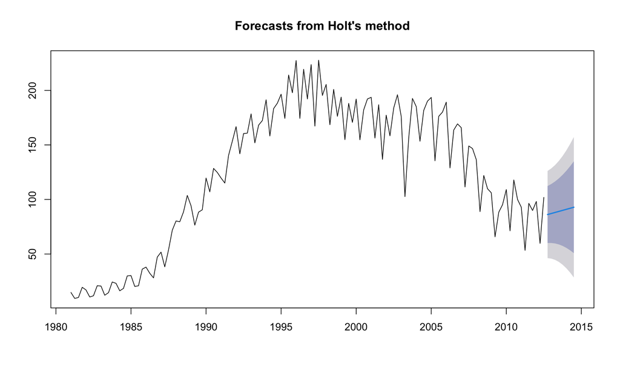

```r
# Holt’s Trend
holt_forecast <- holt(arrivals[,"Japan"], h=8)
plot(holt_forecast)
```

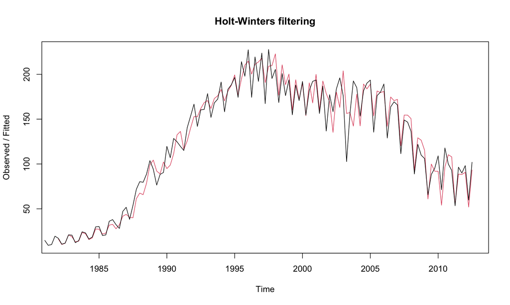

```r
# HoltWinters
HW_forecast<- HoltWinters(arrivals[,"Japan"])
forecast_HW <- forecast(HW_forecast, h=8)
plot(HW_forecast)
```

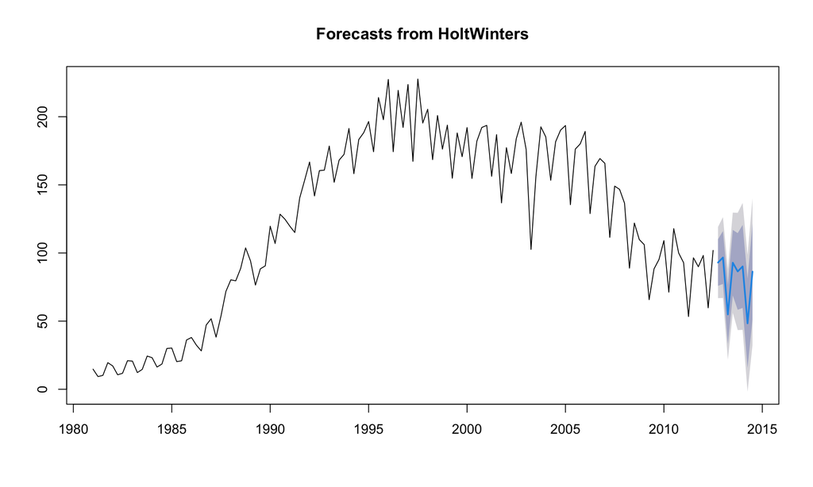

```r
plot(forecast_HW)
```

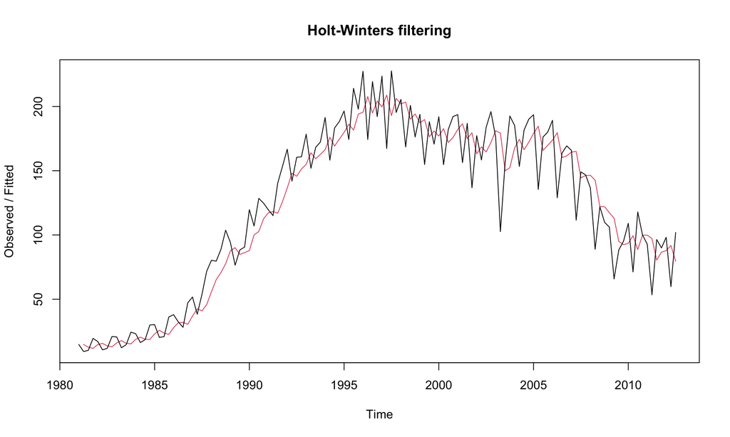

```r
SSE_Simple <- HoltWinters(arrivals[,"Japan"],beta=FALSE,gamma=FALSE)
SSE_forecast <- forecast(SSE_Simple, h = 8)
plot(SSE_Simple)
```

### Decomposition

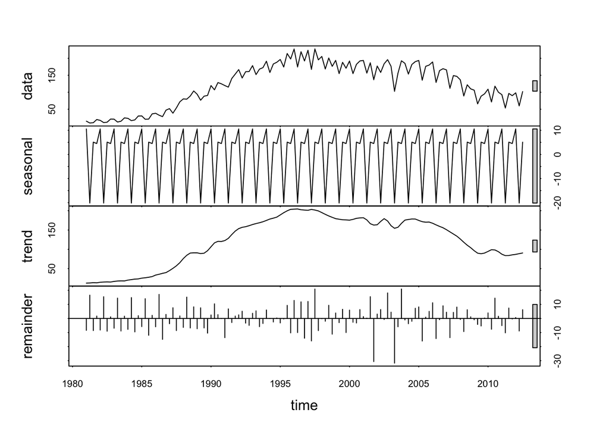

```r
#decomposition
stl_decomp <- stl(arrivals[,"Japan"],s.window ="periodic")
plot(stl_decomp)
```

```r
attributes(stl_decomp)
```

```
## $names
## [1] "time.series" "weights"     "call"        "win"         "deg"
## [6] "jump"        "inner"       "outer"
##
## $class
## [1] "stl"
```

```r
# seasonal adjustment
seasadj(stl_decomp)
```

```
##            Qtr1       Qtr2       Qtr3       Qtr4
## 1981   4.212172  29.468225   5.073598  15.005002
## 1982   6.566172  30.764225   6.644598  16.457002
## 1983  10.120172  32.382225   9.474598  19.859002
## 1984  12.618172  36.443225  13.411598  25.434002
## 1985  19.689172  40.427225  15.815598  31.665002
## 1986  27.438172  52.513225  23.038598  42.646002
## 1987  41.185172  58.401225  48.714598  67.303002
## 1988  69.749172  99.743225  83.615598  99.234002
## 1989  83.621172  96.609225  83.300598  86.023002
## 1990 109.103172 127.112225 123.379598 120.269002
## 1991 109.087172 135.196225 135.377598 148.932002
## 1992 156.181172 162.033225 155.362598 156.303002
## 1993 167.915172 172.051225 163.038598 167.854002
## 1994 180.816172 178.354225 178.196598 183.769002
```

[output cut: 18 more lines]

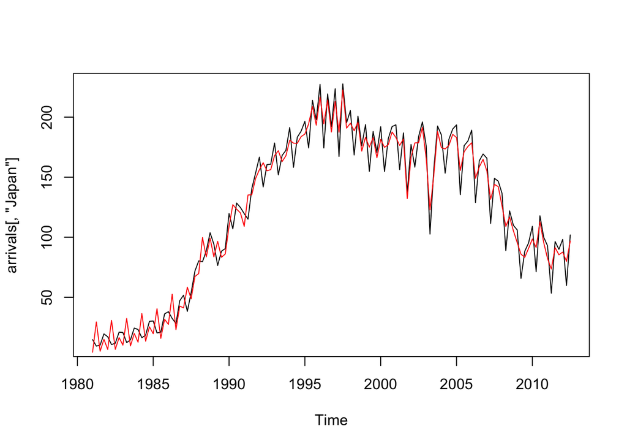

```r
# Plot a line on the graph
plot(arrivals[,"Japan"])
lines(seasadj(stl_decomp), col="Red")
```

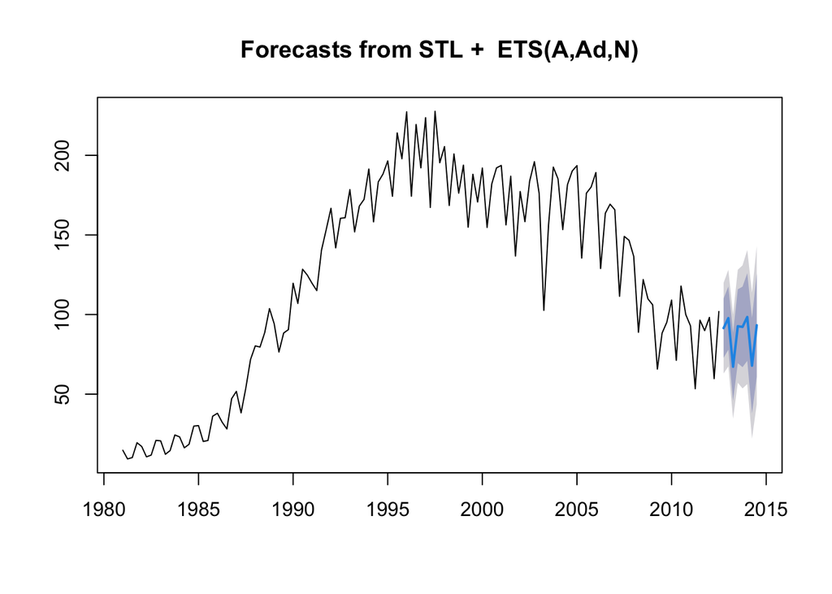

```r
# Default period forecast
f_stl <- forecast(stl_decomp)
# you can pass the # of period
f_stl <- forecast(stl_decomp,h=8)
plot(f_stl)
```

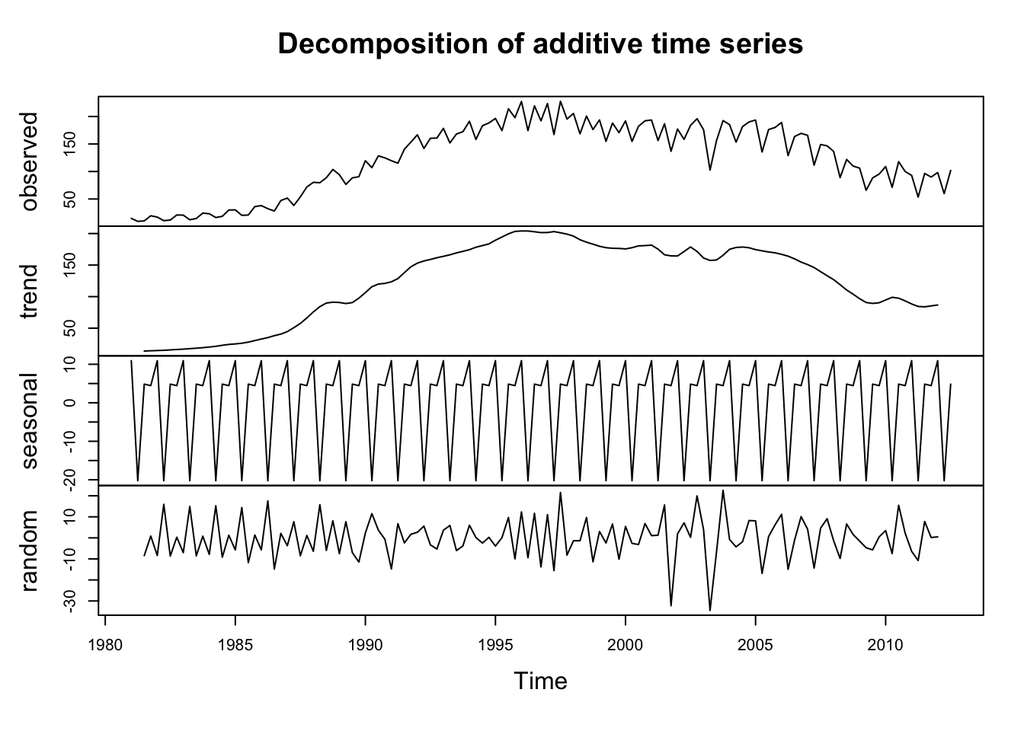

```r
decomp_arr <- decompose(arrivals[,"Japan"])
plot(decomp_arr)
```

```r
attributes(decomp_arr)
```

```
## $names
## [1] "x"        "seasonal" "trend"    "random"   "figure"   "type"
##
## $class
## [1] "decomposed.ts"
```

```r
seasadj(decomp_arr)
```

```
##            Qtr1       Qtr2       Qtr3       Qtr4
## 1981   3.820994  29.567090   5.316716  15.054200
## 1982   6.174994  30.863090   6.887716  16.506200
## 1983   9.728994  32.481090   9.717716  19.908200
## 1984  12.226994  36.542090  13.654716  25.483200
## 1985  19.297994  40.526090  16.058716  31.714200
## 1986  27.046994  52.612090  23.281716  42.695200
## 1987  40.793994  58.500090  48.957716  67.352200
## 1988  69.357994  99.842090  83.858716  99.283200
## 1989  83.229994  96.708090  83.543716  86.072200
## 1990 108.711994 127.211090 123.622716 120.318200
## 1991 108.695994 135.295090 135.620716 148.981200
## 1992 155.789994 162.132090 155.605716 156.352200
## 1993 167.523994 172.150090 163.281716 167.903200
## 1994 180.424994 178.453090 178.439716 183.818200
```

[output cut: 18 more lines]

### 4. Model Interpretation and Comparison

#### Plot: Time Series and Different Forecasts in One Chart

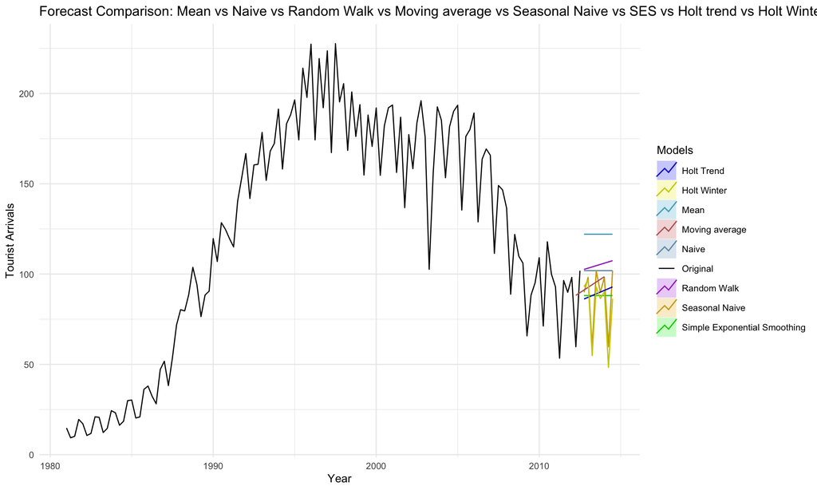

```r
autoplot(arrivals[,"Japan"], series = "Original") +
  autolayer(mean_forecast,   series="Mean", PI=FALSE) +
  autolayer(naive_forecast,  series="Naive", PI=FALSE) +
  autolayer(rwf_forecast,    series="Random Walk", PI=FALSE) +
  autolayer(snaive_forecast, series="Seasonal Naive", PI=FALSE) +
  autolayer(forecast_MA4,   series="Moving average", PI=FALSE) +
  autolayer(ses_forecast,    series="Simple Exponential Smoothing", PI=FALSE) +
  autolayer(holt_forecast,   series="Holt Trend", PI=FALSE) +
  autolayer(forecast_HW,     series="Holt Winter", PI=FALSE) +
  ggtitle("Forecast Comparison: Mean vs Naive vs Random Walk vs Moving average vs Seasonal Naive vs SES vs Holt trend vs Holt Winter") +
  ylab("Tourist Arrivals") +
  xlab("Year") +
  scale_colour_manual(values = c(
    "Original" = "black",
    "Mean" = "skyblue",
    "Naive" = "steelblue",
    "Random Walk" = "purple",
    "Moving average" = "brown",
    "Seasonal Naive" = "orange",
    "Simple Exponential Smoothing" = "green",
    "Holt Trend" = "navy",
    "Holt Winter" = "yellow"
  )) +
  guides(colour = guide_legend(title = "Models")) +
  theme_minimal(base_size = 10)
```

#### The plot above compares multiple forecasting models for Japan’s quarterly tourist arrivals from 1981 to 2012.

- **Mean Model** provides a simple baseline forecast, assuming that future values will remain constant at the historical average level (around 122 thousand).  
  This model ignores both trend and seasonality, serving as a reference point for other models.
- **Naive Model** uses the most recent observation as the forecast for all future periods (around 101 thousand).  
  It assumes no structural change and is typically effective when the time series has strong persistence without clear trends or seasonality.
- **Random Walk with Drift** extends the Naive model by including a drift term that represents a steady upward or downward trend over time.  
  This allows the forecasts to move linearly in the direction of the recent trend, although it still cannot capture seasonal fluctuations.
- **Seasonal Naive Model** captures recurring seasonal patterns by using the value from the same season in the previous year as the forecast.  
  It reproduces seasonal oscillations but does not account for long-term growth or decline trends.
- **Simple Exponential Smoothing (SES)** produces a nearly flat line by assigning exponentially decreasing weights to older observations.  
  It adapts to short-term level changes but ignores both the seasonal and long-term downward movements seen in the Japan arrivals data.
- **Holt’s Trend Method** extends SES by incorporating a trend component, allowing forecasts to follow gradual increases or decreases over time.  
  In this dataset, the forecast line shows a mild upward slope, indicating sensitivity to recent changes in trend.
- **Holt–Winters Model** further adds a seasonal component, making it effective for series with both trend and seasonality—such as quarterly tourist arrivals.  
  The model captures the cyclical oscillations and downward trend observed in the later years of the data.

> Both the Holt–Winters and Seasonal Naive models produce forecasts with seasonal oscillations.  
> However, while the Seasonal Naive model simply repeats the previous year’s seasonal pattern,  
> the Holt–Winters model captures both **trend** and **seasonality**, making it more adaptive to changing seasonal behavior.

### 5. Accuracy Comparison

**Root Mean Squared Error** (RMSE) is selected as the primary accuracy metric to evaluate and compare all forecasting models.

> RMSE is particularly suitable for time series forecasting because it penalizes larger errors more heavily, making it sensitive to model precision and stability

```r
# Create accuracy comparison table
model_comparison <- rbind(
  Mean = accuracy(mean_forecast),
  Naive = accuracy(naive_forecast),
  RandomWalk = accuracy(rwf_forecast),
  MovingAv = accuracy(forecast_MA4),
  SeasonalNaive = accuracy(snaive_forecast),
  sesM = accuracy(ses_forecast),
  holtF = accuracy(holt_forecast),
  HW = accuracy(forecast_HW),
  SSE = accuracy(SSE_forecast),
  stl = accuracy(f_stl)
)

rownames(model_comparison) <- c("Mean Forecast", "Naive", "Random Walk", "Moving Average", "Seasonal Naive","SES", "Holt","Holt Winter", "SSE", "Decomposition")
round(model_comparison[, c("RMSE","MAE","MAPE","MASE")], 3)
```

```
##                  RMSE    MAE    MAPE  MASE
## Mean Forecast  63.961 55.715 135.380 3.848
## Naive          26.346 20.444  20.082 1.412
## Random Walk    26.337 20.369  20.085 1.407
## Moving Average  2.721  1.742   1.506 0.141
## Seasonal Naive 19.541 14.479  14.282 1.000
## SES            21.100 16.038  16.990 1.108
## Holt           20.048 14.946  16.315 1.032
## Holt Winter    13.293  9.566   8.313 0.661
## SSE            21.184 16.162  17.156 1.116
## Decomposition  14.238 10.982  19.376 0.758
```